# Lecture 2: Clutter and Focus

Nick Huntington-Klein

17 March, 2026

## Clutter and Focus

- We want to tell a story with our data
- That is, we want to *demonstrate some interesting finding* from our data
- Some stories are clear
- Others are complex
- They all need to be clear

## Clutter and Focus

- A common mistake is to *show you the data* rather than *show you the story*
- The story often exists within part of the data
- We want to understand some sort of *continuity* or some sort of *distinction*
- Everything that takes away from that makes the story more opaque

## Examples

- Let’s look at some data visualizations that are cluttered
- Some are still *beautiful* and lovely and works of art
- Some are impressive with the amount of information they’re able to get on one graph
- But they can obscure the point they’re trying to make
- With each, let’s think about why

## Bible Cross-References

- The following graph shows how different chapters of the bible refer to each other

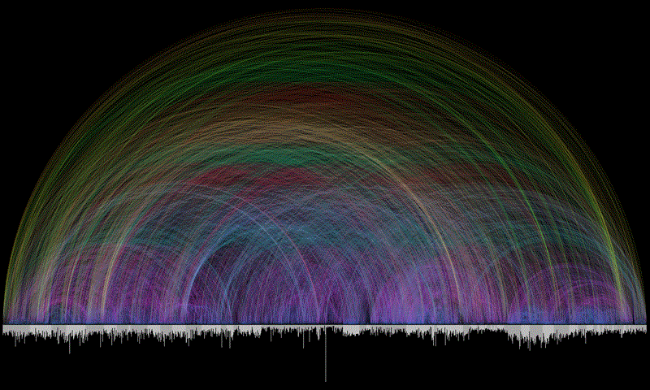

## Coffee

- How much coffee do South Koreans drink?
- Simple question, right?

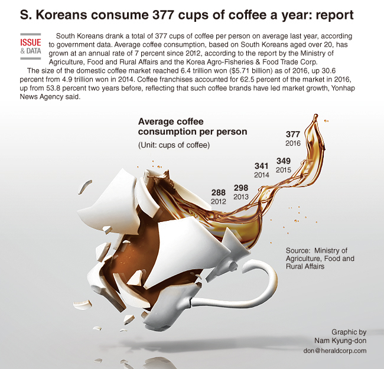

## Health care

- This graph just wants to get across three statistics about health care
- And how those statistics vary by state

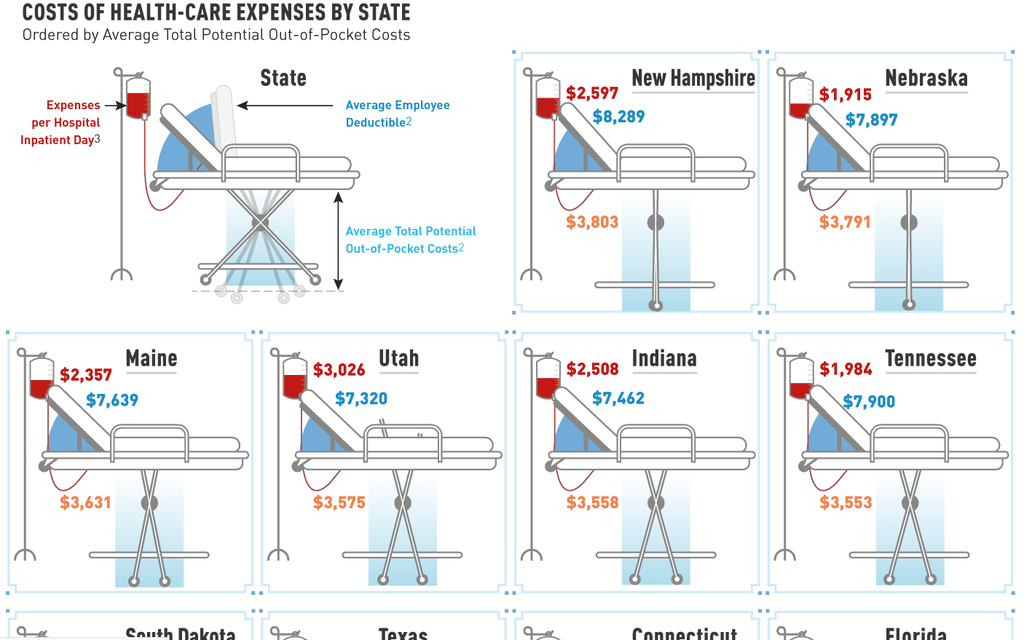

## Network Graphs

- You see a lot of *network graphs* floating around these days
- They look super cool
- But they can be hard to actually learn anything from
- Unless the story is just “things sure are connected, aren’t they?” which isn’t all that interesting

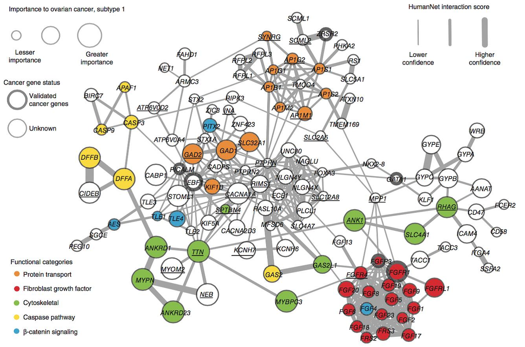

## Napoleon’s March

- This is considered one of the most beautiful and impressive pieces of data viz ever, about Napoleon’s army during its march and retreat from Russia
- Distance from Paris, size of army, elevation, places where the army met itself…
- It absolutely tells an intricate and detailed story - but what can you take away from it if you don’t already know what it’s trying to say?
- What parts of the story does it guide you towards focusing on? Which get lost?

[figure not shown]

## Clutter and Focus

- These graphs vary in quality but some common issues:
- They add things to the graph that do not need to be there or are difficult to understand
- They do not focus your attention on a single takeaway

## Clutter and Focus

- Clutter adds cognitive load - it makes your viz more difficult to understand
- There are many very low-level visual shortcuts in the human brain we can take advantage of to avoid this
- And to make sure that we can anticipate how the reader will interpret the visualization

## Gestalt Principles of Visual Perception

- Proximity
- Similarity
- Enclosure
- Closure
- Continuity
- Connection

## Proximity

- If you put things close to each other, they tend to get thought of as being associated
- And visually, they are at least visually comparable
- Putting two similar things close together says “these things are very similar!”
- Putting two distinct things close together says “compare these please!”
- Basically all good visualizations are about *making a comparison*. Here’s one way you can show people *what comparison they’re supposed to make

## Proximity

|  | Budget |
| --- | --- |
| Sales | $10000 |
| Marketing | $15000 |
| R&D | $5000 |
| HR | $6000 |

## Similarity

- Simply put, things that are made similar in some way (shape, color, shade, etc.) are part of the same whole

Note on using color for this: Remember colorblindness!

- Most common is red/green/(orange), blue/yellow also relatively common
- When picking colors, avoid having your contrasts be red/green or blue/yellow. Red/blue is a popular choice here.
- For complete accessibility, focus on highly contrasting *shades*
- Colorblind-friendly palettes are available!

## Similarity

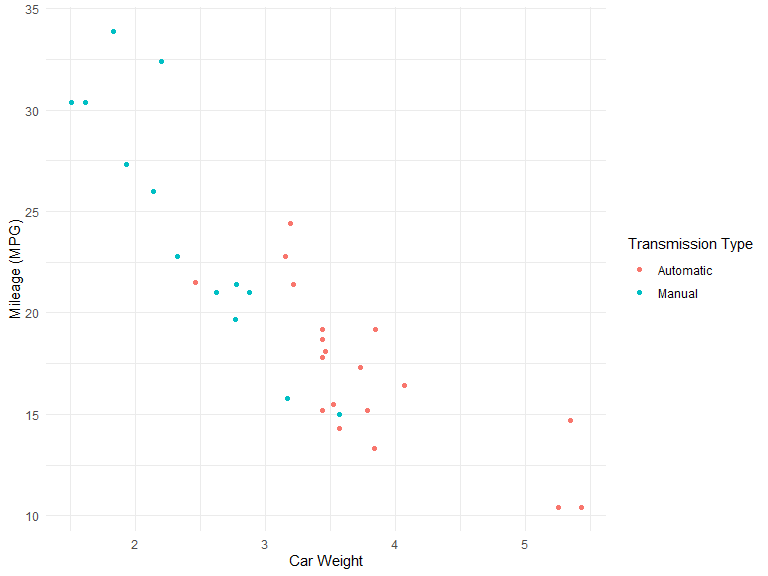

## Enclosure

- If you put a physical enclosure around some things, they will be perceived as being part of a group
- This can be especially handy if you’re already using some other forms of similarity, or need to indicate areas that WOULD be part of that group if you had data there.
- Enclosures say “these things are in a group!” - perhaps you want to compare that group to other things, or focus attention *within* the group?

## Enclosure

[figure not shown]

## Continuity

- When there are gaps, we tend to “fill in” in the most intuitive way

## Continuity

- This year-on-year change graph has a gap at Feb. 29. But what does our brain do?

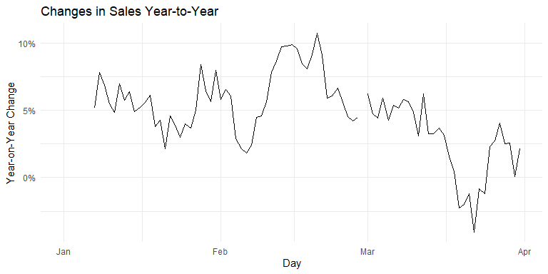

## Connection

- If you put a literal connection between two points, people will interpret them as being connected!
- Connecting two things says “one of these things is adjacent or linked to to the other”
- No big surprise
- See any line graph for this.
- This is also a good reason *not* to use a line graph when your x-axis doesn’t have an order to it!

## How?

- With these concepts in mind, how can we use them to emphasize information?
- And improve clarity
- Let’s begin with a bad first-pass graph and improve it as we can
- Let’s tell a story about how Washington’s 4th graders fare in math vs. other coastal states

## State NAEP Test Scores

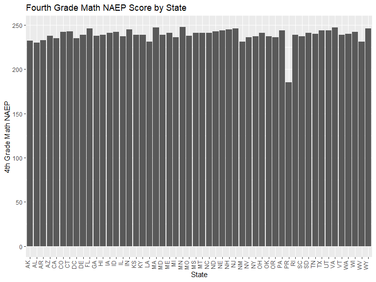

## Ordering Information

- Information should be presented in an order that highlights the information of interest
- Comparisons should be easy to make
- Ask: what should be comparable?
- We should be able to tell “more” or “less” test score
- We use *proximity* to make more-similar scores go together
- **Think**: what bar ordering makes the takeaway as easy to see as possible?

## Proximity: Example

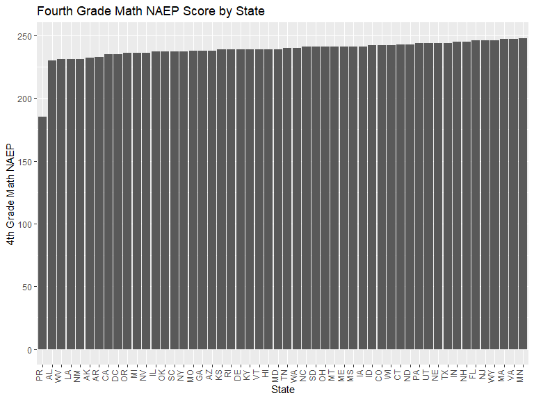

## Using similarity

- We may be interested in comparing Washington vs. other coastal states and saying something about the difference.
- We can do this easily by giving all the coastal states a similar *something*
- With bar graphs, an obvious pick is color

## Similarity: Example

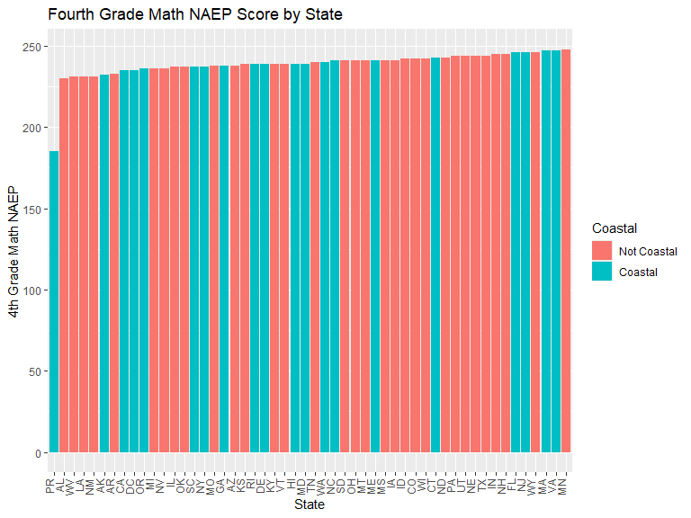

## Clarity

- We have our comparison clarified
- Let’s see what else we can do with this graph

## Slices of Data

- What data is important to our story, and what data is not?
- We are interested in comparing Washington to other coastal states, why do we need all these other states
- Having stuff on the graph says “this is worth your attention somehow.” If it’s not important to the story, it will confuse or distract from the story
- Chuck ’em!
- This will also give us room to rotate those axis labels

## Clarity

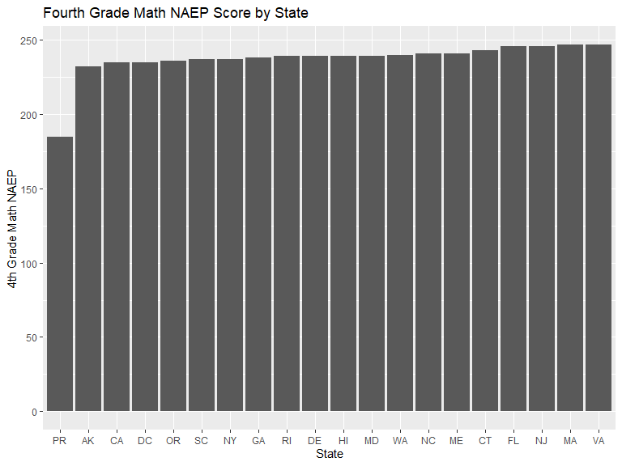

## Contrast

- We can use contrast to make Washington stand out again
- Use a light color for others so they fade more into the back

## Contrast

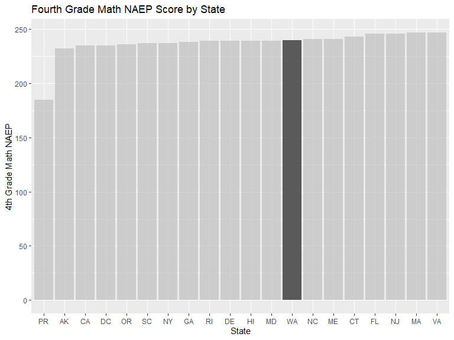

## Simplify

- Enclosure allows us to get rid of a lot of the borders
- And we an remove the backing ink too
- **Don’t underestimate the benefits of removing background ink.** It can really be distracting! Cleaner graphs look cleaner and are often nicer.

## Simplify

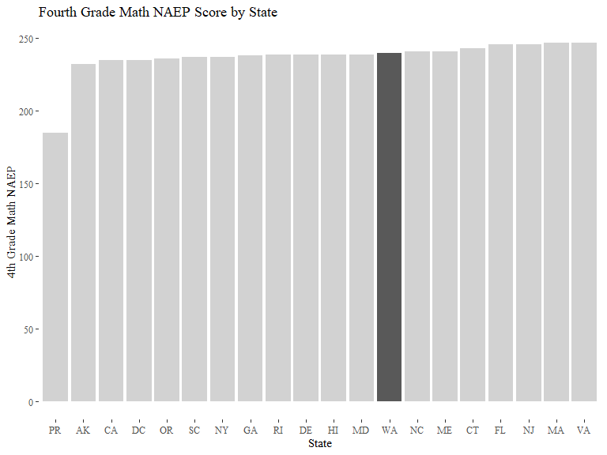

## Easily Following Information

- **Think**: have we made the presentation as easy to see as possible? How could we make it more clear?
- Especially with long text labels, horizontal bar charts are much easier to read and compare

## Easily Following Information

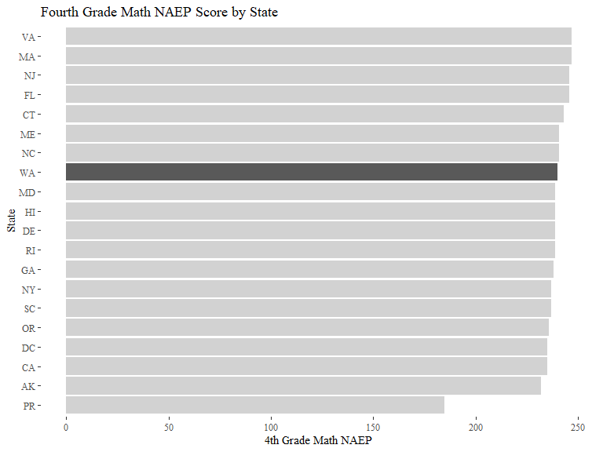

## Label Data Directly

- **Think**: have we provided *affordances*? Have we put the right answer in the place where you’d think to look for it?
- Why make the reader work? Put the label right where it’s needed
- Also, remove the cognitive steps of translating the markers

## Label Data Directly

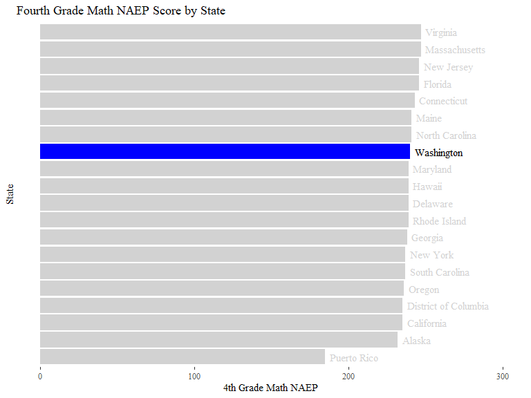

## Now - Your Turn!

- You’ll be creating a graph by hand
- Think carefully about how to make data comparable
- And how to contrast as needed
- And how to tell the story

## Your Turn

- Story: Sales and Marketing may be more expensive, but they haven’t grown as much as R&D and HR.
- Think: what is the *comparison* we want to encourage, and can we see it on your graph?

Costs in thousands of dollars by department by year

| Dept. | Sales | Marketing | R.D | HR |
| --- | --- | --- | --- | --- |
| 2018 | 10000 | 15000 | 5000 | 6000 |
| 2019 | 10500 | 15000 | 7200 | 6500 |
| 2020 | 10600 | 16000 | 9300 | 8000 |